# Case Study: Cyclistic Bike Sharing Company

Ramberto Jr Sosa Cueto

2023-03-06

# Cyclistic Bike Sharing Company

## Case Study Business Task

The goal of the business task is to create a new marketing strategy that will turn occasional riders into annual subscribers for Cyclistic, a hypothetical company. The company’s director of marketing believes that increasing the number of yearly subscriptions is crucial for the long-term success of the company. To achieve this goal, my marketing analyst team, also hypothetical, must understand why casual riders would want to become members, and how annual members use Cyclistic bikes differently from occasional riders. To gain insights that can guide the development of the new marketing strategy, we plan to analyze past bike trip data from Cyclistic. Our aim is to identify patterns and insights that can help us produce compelling data visualizations and expert insights. These visualizations and insights will be used to convince Cyclistic’s management to approve the new marketing strategy.

```r
rm(list=ls()) # Caution: this clears the Environment
```

## Preparing Data

#### Data Sources & Description

The primary data source for this project is historical bicycle trip data from Cyclistic, which can be downloaded via the provided link, https://divvy-tripdata.s3.amazonaws.com/index.html. The dataset includes information about bike trips taken in the past 12 months, such as: • Ride ID • Rideable type • Trip, start time (Include Date and Time in one cell) • Trip, end time (Include Date and Time in one cell) • Trip start station name • Start station ID • Trip end station name • End station ID • Start Latitude • Start Longitude • End Latitude • End Longitude

## Data cleaning, Transformation & Manipulation

#### Loading Data Cleaning Libraries

```r
library(tidyverse)
library(dplyr)
library(readr)
library(lubridate)
```

```r
library(ggplot2)
```

#### Opening csv files containing dataset with readr

```r
table_1 <- "/Users/RambertoJr/Desktop//untitled folder/202202-divvy-tripdata.csv"
cyclistic_data2202 <- read_csv(table_1)
head(cyclistic_data2202)
```

```
## # A tibble: 6 × 13
##   ride_id        ridea…¹ started_at          ended_at            start…² start…³
##   <chr>          <chr>   <dttm>              <dttm>              <chr>   <chr>
## 1 E1E065E7ED285… classi… 2022-02-19 18:08:41 2022-02-19 18:23:56 State … TA1305…
## 2 1602DCDC5B30F… classi… 2022-02-20 17:41:30 2022-02-20 17:45:56 Halste… TA1309…
## 3 BE7DD2AF4B55C… classi… 2022-02-25 18:55:56 2022-02-25 19:09:34 State … TA1305…
## 4 A1789BDF84441… classi… 2022-02-14 11:57:03 2022-02-14 12:04:00 Southp… 13235
## 5 07DE78092C62F… classi… 2022-02-16 05:36:06 2022-02-16 05:39:00 State … TA1305…
## 6 9A2F204F04AB7… classi… 2022-02-07 09:51:57 2022-02-07 10:07:53 St. Cl… 13016
## # … with 7 more variables: end_station_name <chr>, end_station_id <chr>,
## #   start_lat <dbl>, start_lng <dbl>, end_lat <dbl>, end_lng <dbl>,
## #   member_casual <chr>, and abbreviated variable names ¹rideable_type,
## #   ²start_station_name, ³start_station_id
```

```r
table_2 <- "/Users/RambertoJr/Desktop//untitled folder/202203-divvy-tripdata.csv"
cyclistic_data2203 <- read_csv(table_2)
table_3 <- "/Users/RambertoJr/Desktop//untitled folder/202204-divvy-tripdata.csv"
cyclistic_data2204 <- read_csv(table_3)
table_4 <- "/Users/RambertoJr/Desktop//untitled folder/202205-divvy-tripdata.csv"
cyclistic_data2205 <- read_csv(table_4)
table_5 <- "/Users/RambertoJr/Desktop//untitled folder/202206-divvy-tripdata.csv"
cyclistic_data2206 <- read_csv(table_5)
table_6 <- "/Users/RambertoJr/Desktop//untitled folder/202207-divvy-tripdata.csv"
cyclistic_data2207 <- read_csv(table_6)
table_7 <- "/Users/RambertoJr/Desktop//untitled folder/202208-divvy-tripdata.csv"
cyclistic_data2208 <- read_csv(table_7)
table_8 <- "/Users/RambertoJr/Desktop//untitled folder/202209-divvy-tripdata.csv"
cyclistic_data2209 <- read_csv(table_8)
table_9 <- "/Users/RambertoJr/Desktop//untitled folder/202210-divvy-tripdata.csv"
cyclistic_data2210 <- read_csv(table_9)
table_10 <- "/Users/RambertoJr/Desktop//untitled folder/202211-divvy-tripdata.csv"
cyclistic_data2211 <- read_csv(table_10)
table_11 <- "/Users/RambertoJr/Desktop//untitled folder/202212-divvy-tripdata.csv"
cyclistic_data2212 <- read_csv(table_11)
table_12 <- "/Users/RambertoJr/Desktop//untitled folder/202301-divvy-tripdata.csv"
cyclistic_data2301 <- read_csv(table_12)
```

#### Merging all the seperate months into a table, 22-02 to 23-01, with rbind

```r
cyclistic_data_raw <- rbind(cyclistic_data2202, cyclistic_data2203, cyclistic_data2204, cyclistic_data2205, cyclistic_data2206, cyclistic_data2207, cyclistic_data2208, cyclistic_data2209, cyclistic_data2210, cyclistic_data2211, cyclistic_data2212, cyclistic_data2301)
```

#### Looking at the data

```r
head(cyclistic_data_raw)
```

```
## # A tibble: 6 × 13
##   ride_id        ridea…¹ started_at          ended_at            start…² start…³
##   <chr>          <chr>   <dttm>              <dttm>              <chr>   <chr>
## 1 E1E065E7ED285… classi… 2022-02-19 18:08:41 2022-02-19 18:23:56 State … TA1305…
## 2 1602DCDC5B30F… classi… 2022-02-20 17:41:30 2022-02-20 17:45:56 Halste… TA1309…
## 3 BE7DD2AF4B55C… classi… 2022-02-25 18:55:56 2022-02-25 19:09:34 State … TA1305…
## 4 A1789BDF84441… classi… 2022-02-14 11:57:03 2022-02-14 12:04:00 Southp… 13235
## 5 07DE78092C62F… classi… 2022-02-16 05:36:06 2022-02-16 05:39:00 State … TA1305…
## 6 9A2F204F04AB7… classi… 2022-02-07 09:51:57 2022-02-07 10:07:53 St. Cl… 13016
## # … with 7 more variables: end_station_name <chr>, end_station_id <chr>,
## #   start_lat <dbl>, start_lng <dbl>, end_lat <dbl>, end_lng <dbl>,
## #   member_casual <chr>, and abbreviated variable names ¹rideable_type,
## #   ²start_station_name, ³start_station_id
```

```r
str(cyclistic_data_raw)
```

```
## spc_tbl_ [5,754,248 × 13] (S3: spec_tbl_df/tbl_df/tbl/data.frame)
##  $ ride_id           : chr [1:5754248] "E1E065E7ED285C02" "1602DCDC5B30FFE3" "BE7DD2AF4B55C4AF" "A1789BDF844412BE" ...
##  $ rideable_type     : chr [1:5754248] "classic_bike" "classic_bike" "classic_bike" "classic_bike" ...
##  $ started_at        : POSIXct[1:5754248], format: "2022-02-19 18:08:41" "2022-02-20 17:41:30" ...
##  $ ended_at          : POSIXct[1:5754248], format: "2022-02-19 18:23:56" "2022-02-20 17:45:56" ...
##  $ start_station_name: chr [1:5754248] "State St & Randolph St" "Halsted St & Wrightwood Ave" "State St & Randolph St" "Southport Ave & Waveland Ave" ...
##  $ start_station_id  : chr [1:5754248] "TA1305000029" "TA1309000061" "TA1305000029" "13235" ...
##  $ end_station_name  : chr [1:5754248] "Clark St & Lincoln Ave" "Southport Ave & Wrightwood Ave" "Canal St & Adams St" "Broadway & Sheridan Rd" ...
##  $ end_station_id    : chr [1:5754248] "13179" "TA1307000113" "13011" "13323" ...
##  $ start_lat         : num [1:5754248] 41.9 41.9 41.9 41.9 41.9 ...
##  $ start_lng         : num [1:5754248] -87.6 -87.6 -87.6 -87.7 -87.6 ...
##  $ end_lat           : num [1:5754248] 41.9 41.9 41.9 42 41.9 ...
##  $ end_lng           : num [1:5754248] -87.6 -87.7 -87.6 -87.6 -87.6 ...
##  $ member_casual     : chr [1:5754248] "member" "member" "member" "member" ...
##  - attr(*, "spec")=
##   .. cols(
##   ..   ride_id = col_character(),
##   ..   rideable_type = col_character(),
##   ..   started_at = col_datetime(format = ""),
##   ..   ended_at = col_datetime(format = ""),
##   ..   start_station_name = col_character(),
##   ..   start_station_id = col_character(),
##   ..   end_station_name = col_character(),
##   ..   end_station_id = col_character(),
##   ..   start_lat = col_double(),
##   ..   start_lng = col_double(),
##   ..   end_lat = col_double(),
##   ..   end_lng = col_double(),
##   ..   member_casual = col_character()
##   .. )
##  - attr(*, "problems")=<externalptr>
```

The total number of rows is 5,754,248. And Total number of 13

```r
colnames(cyclistic_data_raw)
```

```
##  [1] "ride_id"            "rideable_type"      "started_at"
##  [4] "ended_at"           "start_station_name" "start_station_id"
##  [7] "end_station_name"   "end_station_id"     "start_lat"
## [10] "start_lng"          "end_lat"            "end_lng"
## [13] "member_casual"
```

#### Removing duplicates

```r
cyclistic_data_nodup <- cyclistic_data_raw %>%
  distinct()
```

```r
str(cyclistic_data_nodup)
```

```
## tibble [5,754,248 × 13] (S3: tbl_df/tbl/data.frame)
##  $ ride_id           : chr [1:5754248] "E1E065E7ED285C02" "1602DCDC5B30FFE3" "BE7DD2AF4B55C4AF" "A1789BDF844412BE" ...
##  $ rideable_type     : chr [1:5754248] "classic_bike" "classic_bike" "classic_bike" "classic_bike" ...
##  $ started_at        : POSIXct[1:5754248], format: "2022-02-19 18:08:41" "2022-02-20 17:41:30" ...
##  $ ended_at          : POSIXct[1:5754248], format: "2022-02-19 18:23:56" "2022-02-20 17:45:56" ...
##  $ start_station_name: chr [1:5754248] "State St & Randolph St" "Halsted St & Wrightwood Ave" "State St & Randolph St" "Southport Ave & Waveland Ave" ...
##  $ start_station_id  : chr [1:5754248] "TA1305000029" "TA1309000061" "TA1305000029" "13235" ...
##  $ end_station_name  : chr [1:5754248] "Clark St & Lincoln Ave" "Southport Ave & Wrightwood Ave" "Canal St & Adams St" "Broadway & Sheridan Rd" ...
##  $ end_station_id    : chr [1:5754248] "13179" "TA1307000113" "13011" "13323" ...
##  $ start_lat         : num [1:5754248] 41.9 41.9 41.9 41.9 41.9 ...
##  $ start_lng         : num [1:5754248] -87.6 -87.6 -87.6 -87.7 -87.6 ...
##  $ end_lat           : num [1:5754248] 41.9 41.9 41.9 42 41.9 ...
##  $ end_lng           : num [1:5754248] -87.6 -87.7 -87.6 -87.6 -87.6 ...
##  $ member_casual     : chr [1:5754248] "member" "member" "member" "member" ...
```

Data Doesn’t have duplicates

#### Checking for Misspells

```r
cyclistic_data_raw %>%
  group_by(rideable_type) %>%
  summarize(count = n()) %>%
  arrange(desc(count))
```

```
## # A tibble: 3 × 2
##   rideable_type   count
##   <chr>           <int>
## 1 electric_bike 2939556
## 2 classic_bike  2636441
## 3 docked_bike    178251
```

```r
cyclistic_data_raw %>%
  group_by(start_station_name, start_station_id) %>%
  summarize(count = n()) %>%
  arrange(start_station_name)
```

```
## # A tibble: 1,698 × 3
## # Groups:   start_station_name [1,680]
##    start_station_name                start_station_id count
##    <chr>                             <chr>            <int>
##  1 10101 S Stony Island Ave          922                  3
##  2 111th St - Morgan Park Metra      682                 14
##  3 2112 W Peterson Ave               KA1504000155       977
##  4 532 E 43rd St                     913                 34
##  5 63rd & Western Ave - north corner 739                 14
##  6 63rd & Western Ave - south corner 738                 11
##  7 63rd St Beach                     15491              846
##  8 83rd St (Avalon Park) Metra       665                  2
##  9 900 W Harrison St                 13028            12553
## 10 Abbott Park                       628                 14
## # … with 1,688 more rows
```

```r
cyclistic_data_raw %>%
  group_by(member_casual) %>%
  summarize(count = n()) %>%
  arrange(desc(count))
```

```
## # A tibble: 2 × 2
##   member_casual   count
##   <chr>           <int>
## 1 member        3410728
## 2 casual        2343520
```

```r
cyclistic_data_raw %>%
  group_by(end_station_name, end_station_id) %>%
  summarize(count = n()) %>%
  arrange(end_station_name)
```

```
## # A tibble: 1,715 × 3
## # Groups:   end_station_name [1,697]
##    end_station_name                  end_station_id count
##    <chr>                             <chr>          <int>
##  1 10101 S Stony Island Ave          922                4
##  2 111th St - Morgan Park Metra      682               13
##  3 2112 W Peterson Ave               KA1504000155    1061
##  4 532 E 43rd St                     913               33
##  5 63rd & Western Ave - north corner 739               15
##  6 63rd & Western Ave - south corner 738               10
##  7 63rd St Beach                     15491            910
##  8 83rd St (Avalon Park) Metra       665                3
##  9 900 W Harrison St                 13028          12157
## 10 Abbott Park                       628               20
## # … with 1,705 more rows
```

```r
cyclistic_data_raw %>%
  group_by(start_station_name, start_station_id) %>%
  summarize(count = n()) %>%
  arrange(desc(count))
```

```
## # A tibble: 1,698 × 3
## # Groups:   start_station_name [1,680]
##    start_station_name                 start_station_id  count
##    <chr>                              <chr>             <int>
##  1 <NA>                               <NA>             843525
##  2 Streeter Dr & Grand Ave            13022             75506
##  3 DuSable Lake Shore Dr & Monroe St  13300             41404
##  4 DuSable Lake Shore Dr & North Blvd LF-005            40190
##  5 Michigan Ave & Oak St              13042             39833
##  6 Wells St & Concord Ln              TA1308000050      37938
##  7 Clark St & Elm St                  TA1307000039      35633
##  8 Millennium Park                    13008             35211
##  9 Kingsbury St & Kinzie St           KA1503000043      34151
## 10 Theater on the Lake                TA1308000001      33038
## # … with 1,688 more rows
```

```r
cyclistic_data_raw %>%
  group_by(end_station_name, end_station_id) %>%
  summarize(count = n()) %>%
  arrange(desc(count))
```

```
## # A tibble: 1,715 × 3
## # Groups:   end_station_name [1,697]
##    end_station_name                   end_station_id  count
##    <chr>                              <chr>           <int>
##  1 <NA>                               <NA>           902655
##  2 Streeter Dr & Grand Ave            13022           75656
##  3 DuSable Lake Shore Dr & North Blvd LF-005          42259
##  4 Michigan Ave & Oak St              13042           40336
##  5 DuSable Lake Shore Dr & Monroe St  13300           40196
##  6 Wells St & Concord Ln              TA1308000050    37880
##  7 Millennium Park                    13008           35484
##  8 Clark St & Elm St                  TA1307000039    35064
##  9 Theater on the Lake                TA1308000001    33098
## 10 Kingsbury St & Kinzie St           KA1503000043    32935
## # … with 1,705 more rows
```

The Dataset contain 843525 rows with null values for start_station_name and start_station_id and 902655 rows with null values for end_station_name and end_station_id

#### Filling out nulls using latitude and longitude as reference

```r
cyclistic_data_raw <- cyclistic_data_raw %>%
  unite("start_lat_lng", c(start_lat, start_lng), sep = " ") %>%
  unite("end_lat_lng", c(end_lat, end_lng), sep = " ")
```

```r
cyclistic_data_raw$new_start_station_name <- ifelse(
  is.na(cyclistic_data_raw$start_station_name),
  sub(".*- (.*) /.*", "\\1", cyclistic_data_raw$start_lat_lng),
  cyclistic_data_raw$start_station_name
)
```

```r
cyclistic_data_raw$new_end_station_name <- ifelse(
  is.na(cyclistic_data_raw$end_station_name),
  sub(".*- (.*) /.*", "\\1", cyclistic_data_raw$end_lat_lng),
  cyclistic_data_raw$start_station_name
)
```

#### Looking at the data

```r
head(cyclistic_data_raw)
```

```
## # A tibble: 6 × 13
##   ride_id        ridea…¹ started_at          ended_at            start…² start…³
##   <chr>          <chr>   <dttm>              <dttm>              <chr>   <chr>
## 1 E1E065E7ED285… classi… 2022-02-19 18:08:41 2022-02-19 18:23:56 State … TA1305…
## 2 1602DCDC5B30F… classi… 2022-02-20 17:41:30 2022-02-20 17:45:56 Halste… TA1309…
## 3 BE7DD2AF4B55C… classi… 2022-02-25 18:55:56 2022-02-25 19:09:34 State … TA1305…
## 4 A1789BDF84441… classi… 2022-02-14 11:57:03 2022-02-14 12:04:00 Southp… 13235
## 5 07DE78092C62F… classi… 2022-02-16 05:36:06 2022-02-16 05:39:00 State … TA1305…
## 6 9A2F204F04AB7… classi… 2022-02-07 09:51:57 2022-02-07 10:07:53 St. Cl… 13016
## # … with 7 more variables: end_station_name <chr>, end_station_id <chr>,
## #   start_lat_lng <chr>, end_lat_lng <chr>, member_casual <chr>,
## #   new_start_station_name <chr>, new_end_station_name <chr>, and abbreviated
## #   variable names ¹rideable_type, ²start_station_name, ³start_station_id
```

```r
cyclistic_data_raw %>%
  group_by(new_start_station_name, start_station_id) %>%
  summarize(count = n()) %>%
  arrange(desc(count))
```

```
## # A tibble: 2,320 × 3
## # Groups:   new_start_station_name [2,302]
##    new_start_station_name             start_station_id count
##    <chr>                              <chr>            <int>
##  1 Streeter Dr & Grand Ave            13022            75506
##  2 DuSable Lake Shore Dr & Monroe St  13300            41404
##  3 DuSable Lake Shore Dr & North Blvd LF-005           40190
##  4 Michigan Ave & Oak St              13042            39833
##  5 Wells St & Concord Ln              TA1308000050     37938
##  6 Clark St & Elm St                  TA1307000039     35633
##  7 Millennium Park                    13008            35211
##  8 Kingsbury St & Kinzie St           KA1503000043     34151
##  9 Theater on the Lake                TA1308000001     33038
## 10 Wells St & Elm St                  KA1504000135     31954
## # … with 2,310 more rows
```

```r
cyclistic_data_raw %>%
  group_by(new_end_station_name, end_station_id) %>%
  summarize(count = n()) %>%
  arrange(desc(count))
```

```
## # A tibble: 174,752 × 3
## # Groups:   new_end_station_name [2,447]
##    new_end_station_name end_station_id count
##    <chr>                <chr>          <int>
##  1 41.79 -87.6          <NA>           31493
##  2 41.89 -87.63         <NA>           21484
##  3 41.91 -87.63         <NA>           18258
##  4 41.88 -87.63         <NA>           16937
##  5 41.9 -87.63          <NA>           16636
##  6 41.94 -87.65         <NA>           16285
##  7 41.93 -87.65         <NA>           14408
##  8 41.8 -87.59          <NA>           14361
##  9 41.89 -87.62         <NA>           14320
## 10 41.93 -87.64         <NA>           14131
## # … with 174,742 more rows
```

#### Creating new variables day_of_week to indicate the start date, trip_duration to indicate the length, trip_station_names to indicate the trip and day_time to indicate day time

```r
cyclistic_data_raw <- cyclistic_data_raw %>%
  mutate(day_of_week = weekdays(as.Date(started_at)))
```

```r
cyclistic_data_raw <- cyclistic_data_raw %>%
  unite("trip_station_names", c(new_start_station_name, new_end_station_name), sep = "-")
```

```r
cyclistic_data_raw <- cyclistic_data_raw %>%
  mutate(started_at = ymd_hms(started_at),
         ended_at = ymd_hms(ended_at),
         trip_duration = difftime(ended_at, started_at, units = "mins"))
```

```r
cyclistic_data_raw <- cyclistic_data_raw %>%
  mutate(daytime_start = case_when(
    hour(started_at) < 12 ~ "morning",
    hour(started_at) < 18 ~ "afternoon",
    TRUE ~ "night"
  ),
  daytime_end = case_when(
    hour(ended_at) < 12 ~ "morning",
    hour(ended_at) < 18 ~ "afternoon",
    TRUE ~ "night"
  )
)
```

```r
head(cyclistic_data_raw)
```

```
## # A tibble: 6 × 16
##   ride_id        ridea…¹ started_at          ended_at            start…² start…³
##   <chr>          <chr>   <dttm>              <dttm>              <chr>   <chr>
## 1 E1E065E7ED285… classi… 2022-02-19 18:08:41 2022-02-19 18:23:56 State … TA1305…
## 2 1602DCDC5B30F… classi… 2022-02-20 17:41:30 2022-02-20 17:45:56 Halste… TA1309…
## 3 BE7DD2AF4B55C… classi… 2022-02-25 18:55:56 2022-02-25 19:09:34 State … TA1305…
## 4 A1789BDF84441… classi… 2022-02-14 11:57:03 2022-02-14 12:04:00 Southp… 13235
## 5 07DE78092C62F… classi… 2022-02-16 05:36:06 2022-02-16 05:39:00 State … TA1305…
## 6 9A2F204F04AB7… classi… 2022-02-07 09:51:57 2022-02-07 10:07:53 St. Cl… 13016
## # … with 10 more variables: end_station_name <chr>, end_station_id <chr>,
## #   start_lat_lng <chr>, end_lat_lng <chr>, member_casual <chr>,
## #   trip_station_names <chr>, day_of_week <chr>, trip_duration <drtn>,
## #   daytime_start <chr>, daytime_end <chr>, and abbreviated variable names
## #   ¹rideable_type, ²start_station_name, ³start_station_id
```

```r
cyclistic_data_1 <- cyclistic_data_raw %>%
  arrange(trip_duration)
head(cyclistic_data_1)
```

```
## # A tibble: 6 × 16
##   ride_id        ridea…¹ started_at          ended_at            start…² start…³
##   <chr>          <chr>   <dttm>              <dttm>              <chr>   <chr>
## 1 E137518FFE807… electr… 2022-09-28 11:04:32 2022-09-21 06:31:11 Cornel… 653
## 2 918F745F62CAC… classi… 2022-10-13 14:42:10 2022-10-13 11:53:28 Wilton… chargi…
## 3 38B9F148CE804… electr… 2022-06-07 19:23:03 2022-06-07 17:05:38 <NA>    <NA>
## 4 B897BE02B21FA… electr… 2022-06-07 19:15:39 2022-06-07 17:05:37 <NA>    <NA>
## 5 BF114472ABA02… electr… 2022-06-07 19:14:47 2022-06-07 17:05:42 Base -… Hubbar…
## 6 072E947E156D1… electr… 2022-06-07 19:14:46 2022-06-07 17:07:45 W Armi… 20254.0
## # … with 10 more variables: end_station_name <chr>, end_station_id <chr>,
## #   start_lat_lng <chr>, end_lat_lng <chr>, member_casual <chr>,
## #   trip_station_names <chr>, day_of_week <chr>, trip_duration <drtn>,
## #   daytime_start <chr>, daytime_end <chr>, and abbreviated variable names
## #   ¹rideable_type, ²start_station_name, ³start_station_id
```

The Data shows that there are trips with negative durations

```r
cyclistic_data_filtered <- cyclistic_data_raw %>%
  filter(trip_duration >= 0)
str(cyclistic_data_filtered)
```

```
## tibble [5,754,148 × 16] (S3: tbl_df/tbl/data.frame)
##  $ ride_id           : chr [1:5754148] "E1E065E7ED285C02" "1602DCDC5B30FFE3" "BE7DD2AF4B55C4AF" "A1789BDF844412BE" ...
##  $ rideable_type     : chr [1:5754148] "classic_bike" "classic_bike" "classic_bike" "classic_bike" ...
##  $ started_at        : POSIXct[1:5754148], format: "2022-02-19 18:08:41" "2022-02-20 17:41:30" ...
##  $ ended_at          : POSIXct[1:5754148], format: "2022-02-19 18:23:56" "2022-02-20 17:45:56" ...
##  $ start_station_name: chr [1:5754148] "State St & Randolph St" "Halsted St & Wrightwood Ave" "State St & Randolph St" "Southport Ave & Waveland Ave" ...
##  $ start_station_id  : chr [1:5754148] "TA1305000029" "TA1309000061" "TA1305000029" "13235" ...
##  $ end_station_name  : chr [1:5754148] "Clark St & Lincoln Ave" "Southport Ave & Wrightwood Ave" "Canal St & Adams St" "Broadway & Sheridan Rd" ...
##  $ end_station_id    : chr [1:5754148] "13179" "TA1307000113" "13011" "13323" ...
##  $ start_lat_lng     : chr [1:5754148] "41.8846210725794 -87.6278342306614" "41.929143 -87.649077" "41.8846210725794 -87.6278342306614" "41.94815 -87.66394" ...
##  $ end_lat_lng       : chr [1:5754148] "41.915689 -87.6346" "41.928773 -87.663913" "41.879255 -87.639904" "41.952833 -87.649993" ...
##  $ member_casual     : chr [1:5754148] "member" "member" "member" "member" ...
##  $ trip_station_names: chr [1:5754148] "State St & Randolph St-State St & Randolph St" "Halsted St & Wrightwood Ave-Halsted St & Wrightwood Ave" "State St & Randolph St-State St & Randolph St" "Southport Ave & Waveland Ave-Southport Ave & Waveland Ave" ...
##  $ day_of_week       : chr [1:5754148] "Saturday" "Sunday" "Friday" "Monday" ...
##  $ trip_duration     : 'difftime' num [1:5754148] 15.25 4.43333333333333 13.6333333333333 6.95 ...
##   ..- attr(*, "units")= chr "mins"
##  $ daytime_start     : chr [1:5754148] "night" "afternoon" "night" "morning" ...
##  $ daytime_end       : chr [1:5754148] "night" "afternoon" "night" "afternoon" ...
```

```r
head(cyclistic_data_filtered)
```

```
## # A tibble: 6 × 16
##   ride_id        ridea…¹ started_at          ended_at            start…² start…³
##   <chr>          <chr>   <dttm>              <dttm>              <chr>   <chr>
## 1 E1E065E7ED285… classi… 2022-02-19 18:08:41 2022-02-19 18:23:56 State … TA1305…
## 2 1602DCDC5B30F… classi… 2022-02-20 17:41:30 2022-02-20 17:45:56 Halste… TA1309…
## 3 BE7DD2AF4B55C… classi… 2022-02-25 18:55:56 2022-02-25 19:09:34 State … TA1305…
## 4 A1789BDF84441… classi… 2022-02-14 11:57:03 2022-02-14 12:04:00 Southp… 13235
## 5 07DE78092C62F… classi… 2022-02-16 05:36:06 2022-02-16 05:39:00 State … TA1305…
## 6 9A2F204F04AB7… classi… 2022-02-07 09:51:57 2022-02-07 10:07:53 St. Cl… 13016
## # … with 10 more variables: end_station_name <chr>, end_station_id <chr>,
## #   start_lat_lng <chr>, end_lat_lng <chr>, member_casual <chr>,
## #   trip_station_names <chr>, day_of_week <chr>, trip_duration <drtn>,
## #   daytime_start <chr>, daytime_end <chr>, and abbreviated variable names
## #   ¹rideable_type, ²start_station_name, ³start_station_id
```

A total of 5,754,148 rows are left out of 5,754,248. Only a 100 rows had negative duration.

## Exploratory Analysis

#### Boxplot showing the distribution of trip duration by member/casual:

```
## Defaulting to continuous.
```

[figure not shown]

```r
cyclistic_data_filtered %>%
  ggplot(aes(x = member_casual, y = trip_duration/60, fill = member_casual)) +
  geom_boxplot() +
  ggtitle("Distribution of Trip Duration by Member/Casual") +
  xlab("Member/Casual") +
  ylab("Trip Duration (minutes)") +
  theme_minimal()
```

#### Member vs Casual: Rides Total Sample

```r
cyclistic_data_filtered %>%
  count(member_casual) %>%
  mutate(percent = n/sum(n) * 100)
```

```
## # A tibble: 2 × 3
##   member_casual       n percent
##   <chr>           <int>   <dbl>
## 1 casual        2343465    40.7
## 2 member        3410683    59.3
```

#### Member vs Causal: Trips Duration in Minutes

```r
cyclistic_data_filtered %>%
    group_by(member_casual) %>%
  summarize(mean_trip_duration = mean(trip_duration))
```

```
## # A tibble: 2 × 2
##   member_casual mean_trip_duration
##   <chr>         <drtn>
## 1 casual        29.02961 mins
## 2 member        12.62867 mins
```

#### Member vs Casual: Rides by Rideable Type & Trip Duration

```r
cyclistic_data_filtered %>%
  group_by(member_casual, rideable_type) %>%
  summarise(trip_count = n(),
            avg_trip_duration = mean(trip_duration, na.rm = TRUE)) %>%
  arrange(member_casual, desc(trip_count))
```

```
## # A tibble: 5 × 4
## # Groups:   member_casual [2]
##   member_casual rideable_type trip_count avg_trip_duration
##   <chr>         <chr>              <int> <drtn>
## 1 casual        electric_bike    1266836  16.07797 mins
## 2 casual        classic_bike      898378  28.63976 mins
## 3 casual        docked_bike       178251 123.04221 mins
## 4 member        classic_bike     1738035  13.81036 mins
## 5 member        electric_bike    1672648  11.40078 mins
```

#### Member vs Casual: Rides by Day of the Week

```r
cyclistic_data_filtered %>%
  group_by(member_casual, day_of_week) %>%
  summarise(trip_count = n(),
            avg_trip_duration = mean(trip_duration, na.rm = TRUE)) %>%
  arrange(member_casual, desc(trip_count))
```

```
## # A tibble: 14 × 4
## # Groups:   member_casual [2]
##    member_casual day_of_week trip_count avg_trip_duration
##    <chr>         <chr>            <int> <drtn>
##  1 casual        Saturday        474411 32.49762 mins
##  2 casual        Sunday          392873 34.09311 mins
##  3 casual        Friday          337251 27.95366 mins
##  4 casual        Thursday        311806 25.40727 mins
##  5 casual        Monday          280940 29.05260 mins
##  6 casual        Wednesday       277943 24.52834 mins
##  7 casual        Tuesday         268241 25.68337 mins
##  8 member        Thursday        540889 12.20727 mins
##  9 member        Wednesday       535825 12.02408 mins
## 10 member        Tuesday         534240 12.01524 mins
## 11 member        Monday          482610 12.20072 mins
## 12 member        Friday          475840 12.45940 mins
## 13 member        Saturday        447076 14.07111 mins
## 14 member        Sunday          394203 13.95232 mins
```

```r
cyclistic_data_filtered %>%
  group_by(member_casual, daytime_start, day_of_week) %>%
  summarise(trip_count = n(),
            avg_trip_duration = mean(trip_duration, na.rm = TRUE)) %>%
  arrange(member_casual,desc(trip_count))
```

```
## # A tibble: 42 × 5
## # Groups:   member_casual, daytime_start [6]
##    member_casual daytime_start day_of_week trip_count avg_trip_duration
##    <chr>         <chr>         <chr>            <int> <drtn>
##  1 casual        afternoon     Saturday        224012 32.33986 mins
##  2 casual        afternoon     Sunday          193539 33.93847 mins
##  3 casual        afternoon     Friday          149168 28.22496 mins
##  4 casual        night         Saturday        132414 33.53363 mins
##  5 casual        afternoon     Thursday        131615 27.49374 mins
##  6 casual        afternoon     Monday          130004 30.00215 mins
##  7 casual        morning       Saturday        117985 31.63445 mins
##  8 casual        afternoon     Wednesday       116024 24.77198 mins
##  9 casual        afternoon     Tuesday         115785 25.81811 mins
## 10 casual        morning       Sunday          113255 34.41339 mins
## # … with 32 more rows
```

#### Member vs Casual: Rides by Daytime & Day of the Week

```r
cyclistic_data_filtered %>%
  group_by(member_casual, daytime_start, day_of_week) %>%
  summarise(trip_count = n(),
            avg_trip_duration = mean(trip_duration, na.rm = TRUE)) %>%
  arrange(member_casual,desc(trip_count))
```

```
## # A tibble: 42 × 5
## # Groups:   member_casual, daytime_start [6]
##    member_casual daytime_start day_of_week trip_count avg_trip_duration
##    <chr>         <chr>         <chr>            <int> <drtn>
##  1 casual        afternoon     Saturday        224012 32.33986 mins
##  2 casual        afternoon     Sunday          193539 33.93847 mins
##  3 casual        afternoon     Friday          149168 28.22496 mins
##  4 casual        night         Saturday        132414 33.53363 mins
##  5 casual        afternoon     Thursday        131615 27.49374 mins
##  6 casual        afternoon     Monday          130004 30.00215 mins
##  7 casual        morning       Saturday        117985 31.63445 mins
##  8 casual        afternoon     Wednesday       116024 24.77198 mins
##  9 casual        afternoon     Tuesday         115785 25.81811 mins
## 10 casual        morning       Sunday          113255 34.41339 mins
## # … with 32 more rows
```

#### Member vs Casual: Rides by Start Station Name

```r
cyclistic_data_filtered %>%
  group_by(member_casual, start_station_name) %>%
  summarise(trip_count = n(),
            avg_trip_duration = mean(trip_duration, na.rm = TRUE)) %>%
  arrange(desc(trip_count))
```

```
## # A tibble: 3,104 × 4
## # Groups:   member_casual [2]
##    member_casual start_station_name                 trip_count avg_trip_duration
##    <chr>         <chr>                                   <int> <drtn>
##  1 member        <NA>                                   493449 11.949824 mins
##  2 casual        <NA>                                   350053 14.620110 mins
##  3 casual        Streeter Dr & Grand Ave                 58269 47.737130 mins
##  4 casual        DuSable Lake Shore Dr & Monroe St       31980 47.869334 mins
##  5 casual        Millennium Park                         25680 56.754811 mins
##  6 casual        Michigan Ave & Oak St                   25326 39.165855 mins
##  7 member        Kingsbury St & Kinzie St                25239  9.545925 mins
##  8 casual        DuSable Lake Shore Dr & North Blvd      23700 36.713544 mins
##  9 member        Clark St & Elm St                       22515 12.333987 mins
## 10 member        Wells St & Concord Ln                   21595 11.806319 mins
## # … with 3,094 more rows
```

## Data Vialization

#### Create a new column with month-year format

```r
cyclistic_data_filtered$date <- format(as.Date(cyclistic_data_filtered$started_at), "%Y-%m")
```

#### Group data by month-year and member_casual, and count the number of rides

```r
rides_per_month <- cyclistic_data_filtered %>%
  group_by(date, member_casual) %>%
  summarise(num_rides = n())
```

#### Plot the number of rides by month-year

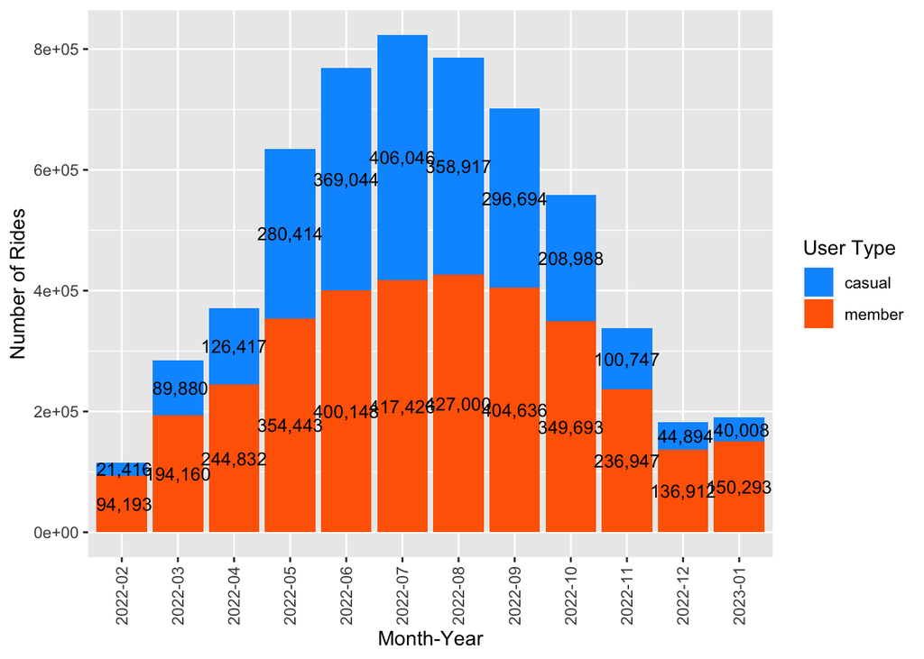

```r
ggplot(rides_per_month, aes(x = date, y = num_rides, fill = member_casual)) +
  geom_col() +
  labs(x = "Month-Year", y = "Number of Rides", fill = "User Type") +
  scale_fill_manual(values = c("#0099FF", "#FF6600")) +
  theme(axis.text.x = element_text(angle = 90, vjust = 0.5, hjust=1)) +
  geom_text(aes(label = format(num_rides, big.mark = ",")), position = position_stack(vjust = 0.5), size = 3.5)
```

#### Stacked bar chart showing the number of rides per day of the week:

[figure not shown]

```r
cyclistic_data_filtered %>%
  count(day_of_week, member_casual, sort = TRUE) %>%
  mutate(n = scales::comma(n)) %>%
  ggplot(aes(x = factor(day_of_week, levels = c("Monday", "Tuesday", "Wednesday", "Thursday", "Friday", "Saturday", "Sunday")), y = n, fill = member_casual)) +
  geom_col(position = "stack") +
  geom_text(aes(label = n, group = member_casual),
            position = position_stack(vjust = 0.5),
            size = 3,
            fontface = "bold") +
  ggtitle("Number of Rides per Day of Week and Member/Casual") +
  xlab("Day of Week") +
  ylab("Number of Rides") +
  theme_minimal()
```

#### This create plots for rideable type

#### Create a bar plot to show the difference in trip count by rideable type

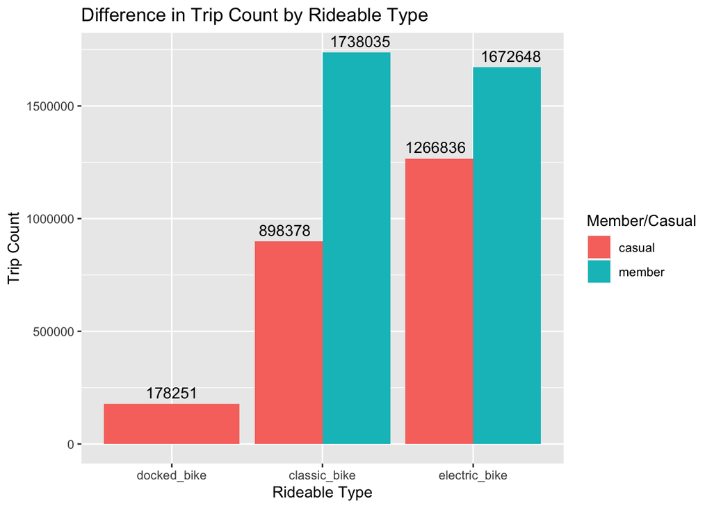

```r
rideable_type_plot <- cyclistic_data_filtered %>%
  group_by(member_casual, rideable_type) %>%
  summarise(trip_count = n(),
            avg_trip_duration = mean(trip_duration, na.rm = TRUE)) %>%
  ungroup() %>%
  arrange(desc(-trip_count))
ggplot(rideable_type_plot, aes(x = factor(rideable_type, levels = c("docked_bike", "classic_bike", "electric_bike")), y = trip_count, fill = member_casual)) +
  geom_col(position = "dodge") +
  labs(title = "Difference in Trip Count by Rideable Type", x = "Rideable Type", y = "Trip Count", fill = "Member/Casual") +
  geom_text(aes(label = trip_count), position = position_dodge(width = 1), vjust = -0.5)
```

#### This shows how to create plots for daytime start

#### Create a bar plot to show the difference in trip count by daytime start

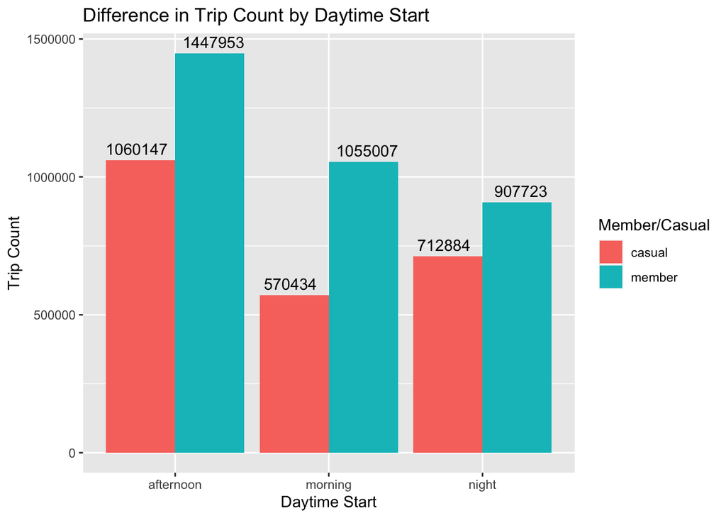

```r
daytime_start_plot <- cyclistic_data_filtered %>%
  group_by(member_casual, daytime_start) %>%
  summarise(trip_count = n(),
            avg_trip_duration = mean(trip_duration, na.rm = TRUE)) %>%
  ungroup()  %>%
  arrange(desc(trip_count))
ggplot(daytime_start_plot, aes(x = daytime_start, y = trip_count, fill = member_casual)) +
  geom_col(position = "dodge") +
  labs(title = "Difference in Trip Count by Daytime Start", x = "Daytime Start", y = "Trip Count", fill = "Member/Casual") +
  geom_text(aes(label = trip_count), position = position_dodge(width = 1), vjust = -0.5)
```

#### Group and summarise the data by start station name and member/casual status

#### Sort the data by total trip count for each station

#### Limit the data to the top stations based on the number of trips

#### Filter the original data to include only the top stations

#### Accounting for nulls

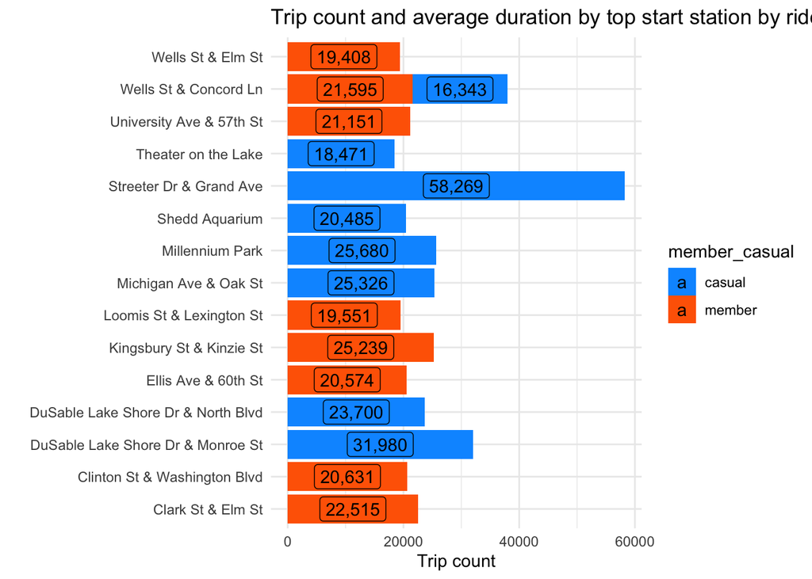

```r
cyclistic_data_filtered %>%
  filter(!is.na(start_station_name)) %>%
  group_by(member_casual, start_station_name) %>%
  summarise(trip_count = n(),
            avg_trip_duration = mean(trip_duration, na.rm = TRUE)) %>%
  arrange(desc(-trip_count)) %>%
  top_n(8, trip_count) %>%
  ggplot(aes(x = trip_count, y = start_station_name, fill = member_casual)) +
  geom_col(position = "stack") +
  scale_fill_manual(values = c("#0099FF", "#FF6600")) +
  labs(title = "Trip count and average duration by top start station by rides vs member/casual",
       x = "Trip count", y = "") +
  theme_minimal() +
  geom_label(aes(label=format(trip_count, big.mark=",")), position = position_stack(vjust = 0.5))
```

## Recommendations Base on the Analysis

Overall, the focus should be on providing attractive incentives for casual riders to become annual members, while also highlighting the benefits of annual membership and targeting the busiest days and stations with promotional offers.